# Computational Search for Toxicologically Relevant NR’s TF’s using Machine Learning

The genes of interest are: CYP … 3A4, 2C9, 2C8, 2E1, 1A2

2A6, 2D6, 2B6, 2C19, 3A5

2J2, 1A1, and 1B1

Agnostic Pipeline: Download Encode Acessible Regions in Liver -> Extract Sequences using BED and DEEP TOOL -> DREME-Chip Search for Binding Motifs -> Cross Reference With ChipSeq Data -> Visualize using cytoscape

Literature Based Pipeline: Download Accessible Regions Using Cytoscape -> Extract Sequencess using BED and DEEP TOOL -> Cross Reference with JASPAR with Known TF’s -> Cytoscape visualizaiton

This will be the proof of concept Eventually we want to replace Step 3 of each pipeline with a Machine Learning Classifier

Possible Future Ideas: TF Prediction -> SNP cataloging -> Precision Medicine Experimental Validation

SNP Predictive Algorithms?

Extracting Transcription Binding Candidates (TBC)

Setting Up dependencies

```r
library(biomaRt)
library(dplyr)
library(tidyverse)
library(seqinr)
library(Biostrings)
library(TFBSTools)
```

```r
library(seqLogo)
library(JASPAR2018)
library(reshape2)
library(ggplot2)
library(nucleR)
library(rtracklayer)
```

Getting Gene Coordinates

```r
mart <- useMart(biomart="ENSEMBL_MART_ENSEMBL", host="grch37.ensembl.org", path="/biomart/martservice", dataset="hsapiens_gene_ensembl")
#Genes of interest
cyp <- c('ENSG00000160868','ENSG00000138109','ENSG00000138115','ENSG00000130649','ENSG00000140505','ENSG00000255974','ENSG00000100197','ENSG00000197408','ENSG00000165841','ENSG00000106258','ENSG00000134716','ENSG00000140465','ENSG00000138061')
#Getting gene annotation
ann <- getBM(c("hgnc_symbol","description","chromosome_name","band","strand","start_position","end_position","ensembl_gene_id"), "ensembl_gene_id", cyp, mart)
```

```r
gen_loc <- ann  %>%
  select(c('chromosome_name', 'start_position', 'end_position', 'ensembl_gene_id'))
gen_loc$chromosome_name <- paste('chr', gen_loc$chromosome_name, sep = '')
```

Loading DNA accessibility data from following Encode Data Sets: ENCSR149XIL ENCSR555QAY ENCSR000ENP ENCSR000DCH ENCSR373TDL ENCSR000DCW

```r
file <- '~/Documents/sudin_pipeline/data/liver_euchormatin/ENCFF435SDA_Hg19_HepG2_DNaseISeq.bed.gz'
nar_pek_var <- c('chrom', 'chromstart', 'chromend', 'name', 'score','strand', 'signalvalue', 'pvalue', 'qvalue', 'peak')
tbc <- read_tsv(file, col_names = nar_pek_var)
```

All at once relevant TBC for each gene

```r
cyp_reg <- c()
for (i in 1:length(gen_loc$chromosome_name)){
  j <- filter(tbc, chrom == gen_loc[[i, 1]] & chromstart > gen_loc[[i, 2]]-10000 & chromend < gen_loc[[i, 3]]+10000)
  cyp_reg <- c(cyp_reg, j)
}
```

Building frequency tibble for plotting to find appropriate proximal upstream and downstream lengths for calculating

```r
bounds <- seq(1000, 20000, 1000)
dat <- tibble()
for (i in bounds){
  for (j in 1:length(gen_loc$chromosome_name)){
    r <- nrow(filter(tbc, chrom == gen_loc[[j, 1]] & chromstart > gen_loc[[j, 2]]-i & chromend < gen_loc[[j, 3]]+i))
    dat <- bind_rows(dat, c(freq = r, bound = i, gene = gen_loc[[j, 4]]))
  }
}
dat$bound <- as.numeric(dat$bound)
dat$freq <- as.numeric(dat$freq)
```

Building stacked bargraph to visualize TBC frequency at differing proximal lengths

```
Ignoring unknown parameters: binwidth, bins, pad
```

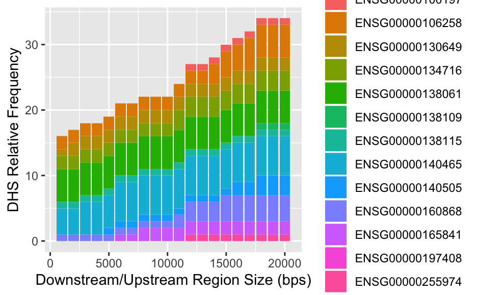

```r
ggplot(dat, aes(x = bound,y = freq,  fill = gene)) +
  geom_histogram(stat = 'identity') +
  ylab("DHS Relative Frequency") +
  xlab("Downstream/Upstream Region Size (bps)")
```

```
Ignoring unknown parameters: binwidth, bins, pad
```

[figure not shown]

```r
ggplot(dat, aes(x = bound,y = freq/50,  fill = gene)) +
  geom_histogram(stat = 'identity') +
  ylab("DHS Relative Frequency") +
  xlab("Downstream/Upstream Region Size (bps)")
```

I will use 10K bps as my proximal regions of interest.

So now I want to use Jaspar to cross refercene TF’s of interest against the regions of interest. I now need to write up my TF’s of interest and then use Jaspar to find those motifs.

In the meantime we can use Meme-Chip to find these Denovo

So now we need to create a system that will download the DNA based on some gene coordinates [chr[i], start, end]

To do that we will read from 2bit files to reduce memory strain

Test getting sequence from genome

```r
genome <- TwoBitFile('../data/hg19.2bit')
test_loc <- GRanges('chr10', IRanges(12129441, 12129591))
test_seq <- as.character(import(genome, which = test_loc))
```

Trying to get all regulatory regions

```r
reg_seqs_vec <- tibble()
for (i in 1:length(gen_loc$chromosome_name)){
  j <- filter(tbc, chrom == gen_loc[[i, 1]] & chromstart > gen_loc[[i, 2]]-10000 & chromend < gen_loc[[i, 3]]+10000)
  gene <- gen_loc[[i,4]]
  locs <- GRanges(j$chrom, IRanges(j$chromstart, j$chromend))
  seqs <- as.character(import(genome, which = locs))
  if (length(seqs) > 0){
    reg_seqs_vec <- bind_rows(reg_seqs_vec, tibble(rep(gene,length(seqs)), seqs))
  }
}
colnames(reg_seqs_vec) <- c('ensemblID', 'Sequence')
```

Getting Distal Elements

```r
tbde <- read_tsv('../data/allGeneCorrelations100000.p05_v3.txt')
cyp_names <- c('CYP3A4','CYP2C9','CYP2C8','CYP2E1','CYP1A2','CYP2A6','CYP2D6','CYP2B6','CYP2C19','CYP3A5','CYP2J2','CYP1A1','CYP1B1')
de <- tbde %>%
  filter(grepl(pattern = paste(cyp_names,collapse ='|'), x = gene_name, ignore.case = TRUE)) %>%
  filter(!gene_name == 'CYP3A43') %>%
  filter(pval < 0.05)
```

```r
ensemblID <- tibble(de$ensemblID)
loc <- GRanges(de$dhs_chr, IRanges(de$dhs_start,de$dhs_end))
sequences <- tibble(as.character(import(genome, which = loc)))
de_seqs_vec <- cbind(ensemblID, sequences)
colnames(de_seqs_vec) <- c('ensemblID', 'sequence')
```

Finding Motifs from Jaspar for relevant TFS: ESR1, NR3C1, RARA, HNF4A, CAR, PXR, VDR, PPARA, AHR CAR abd PXR were not found from JASPAR 2018 : Will need to see

I want to get the data for the TF’s above

I want to get all of them This script is missing CAR, PXR

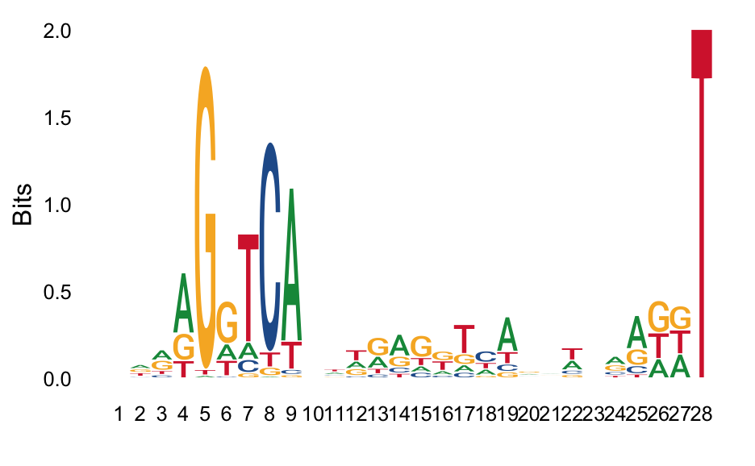

```r
#Getting PWM for each TF binding site
tf <- c('ESR1', 'NR3C1', 'RARA','RARA(var.2)', 'RARA::RXRA', 'PPARA::RXRA', 'HNF4A', 'VDR','RXRA::VDR', 'Ahr::Arnt')
tf_pfm <- c()
tf_pwm <- c()
for (i in 1:length(tf)){
  tf_pfm <- getMatrixByName(JASPAR2018, tf[i])
  tf_pwm <- c(tf_pwm, toPWM(tf_pfm))
}
#For CAR NR
#Hosada et. al
require(ggseqlogo)
hosadaFile <- '../data/car_binding_sites_hosoda.tsv'
hosadaFileHeader <- c('number', 'loc', 'len', 'bs', 'motif', 'compete10', 'compete100')
hCarHosada <- read_tsv(hosadaFile, col_names = hosadaFileHeader, skip = 1)
hCarHosada <- filter(hCarHosada,  !is.na(bs))
hCarHosada <- mutate_all(hCarHosada, .funs=toupper)
siteSeqs <- hCarHosada$bs
#Make Postion Frequency Matrix
countMatrix <- consensusMatrix(siteSeqs)
pfm <- PFMatrix(ID = 'CAR', name = 'CAR-RXRA', profileMatrix = countMatrix)
ggseqlogo(countMatrix)
```

```r
pwm <- toPWM(pfm)
tf_PWM <- c(tf_pwm, pwm)
```

Putting all the data together for analysis

```r
#Concatenating all my data
#DE Data
cyp_reg_data <- tibble(reg_gene = de_seqs_vec$ensemblID,
                       seq = de_seqs_vec$sequence,
                       dhs_chrom = de$dhs_chr,
                       dhs_start = de$dhs_start,
                       dhs_end = de$dhs_end,
                       de = 1
)
#+/- 10000 bp region
for (i in 1:length(gen_loc$chromosome_name)){
  j <- filter(tbc, chrom == gen_loc[[i, 1]] & chromstart > gen_loc[[i, 2]]-10000 & chromend < gen_loc[[i, 3]]+10000)
  gene <- gen_loc[[i,4]]
  locs <- GRanges(j$chrom, IRanges(j$chromstart, j$chromend))
  seqs <- as.character(import(genome, which = locs))
  if (length(seqs) > 0){
    k <- tibble(reg_gene = gen_loc$ensembl_gene_id[i],
           seq = seqs,
           dhs_chrom = j$chrom,
           dhs_start = j$chromstart,
           dhs_end = j$chromend,
           de = 0
    )
    cyp_reg_data <- rbind(cyp_reg_data, k)
  }
}
```

Since we are illustrating the problem we will use unaltered PWMs There will be a relaxed PWM to create a wider “net”

```r
tf <- c('ESR1', 'NR3C1', 'RARA','RARA(var.2)', 'RARA::RXRA', 'PPARA::RXRA', 'HNF4A', 'VDR','RXRA::VDR', 'Ahr::Arnt')
frequency <- c()
for (p in 60:90){
  longSites <- tibble(seq = character(),
                    chrom = character(),
                    start_coord = integer(),
                    end_coord = integer(),
                    ensembl = character(),
                    de = integer(),
                    tf = character()
                    )
  for (i in 1:length(tf)){
    #Getting PWM from Jaspar2018
    tf_pfm <- getMatrixByName(JASPAR2018, tf[i])
    tf_pwm <- toPWM(tf_pfm)
    TF <- tf[i]
    for (j in 1:length(cyp_reg_data$seq)){
      #Define Gene of interest
      gene <- cyp_reg_data$reg_gene[j]
      #Defining Peak Location
      peak_chrom2 <- cyp_reg_data$dhs_chrom[j]
      peak_start <- cyp_reg_data$dhs_start[j]
      # Search sequence for relaxed match to each tf
      mySeqDNAString <- DNAString(c2s(cyp_reg_data$seq[j]))
      siteSet <- searchSeq(tf_pwm, mySeqDNAString,
                           seqname = "seq1", min.score = paste0(as.character(p),"%"), strand = "*")
      sites_in_myseq <- writeGFF3(siteSet)
      de_sing <-  cyp_reg_data$de[j]
      # If binding sites found, add all instances to dataframe of sites
      numSites_in_myseq <- dim(sites_in_myseq)[1]
      if (numSites_in_myseq > 0) {
        cat("* Found ", numSites_in_myseq, " putative REs in peak # ", j, " \n")

        # Loop over DREs
        for (k in 1:numSites_in_myseq) {
          # Find start and end coords of site
          start <- sites_in_myseq$start[k]
          end <- sites_in_myseq$end[k]

          # Ignore sites too close to end of sequence string
          if ((start <= 7) || (end >= length(mySeqDNAString) - 7)) {
            next
          }

          if (sites_in_myseq$strand[k] == "+") {
            long_site <- mySeqDNAString[(start - 7):(end + 7)]
          } else {
            long_site <- reverseComplement(mySeqDNAString[(start - 7):(end + 7)])
          }
          #cat("DRE no. = ", j, "\n")
          long_site_string <- toString(long_site)
          start_long_site = (start - 7)
          end_long_site = (end + 7)
          temp_df <- data.frame(seq = long_site_string,
                                chrom = peak_chrom2,
                                start_coord = start_long_site + peak_start,
                                end_coord = end_long_site + peak_start,
                                ensembl = gene,
                                de = de_sing,
                                tf = TF
                                )
          longSites <- rbind(longSites, temp_df)
        }
      }
    }
  }
  frequency <- c(frequency,length(longSites$seq))
}
```